# TP1

MartinFeijoo

2025-04-06

# 1 Análisis Exploratorio Inicial

## 1.1 Muestro los valores de cada columna

```r
df <- as.data.frame(select(cafe_sales_df, "Item", "Quantity", "Payment Method", "Location"))
head(df, 20)
```

```
##        Item Quantity Payment Method Location
## 1    Coffee        2    Credit Card Takeaway
## 2      Cake        4           Cash In-store
## 3    Cookie        4    Credit Card In-store
## 4     Salad        2        UNKNOWN  UNKNOWN
## 5    Coffee        2 Digital Wallet In-store
## 6  Smoothie        5    Credit Card     <NA>
## 7   UNKNOWN        3          ERROR Takeaway
## 8  Sandwich        4           Cash  UNKNOWN
## 9      <NA>        5           <NA> Takeaway
## 10 Sandwich        5           <NA> In-store
## 11    Salad        5           Cash Takeaway
## 12 Sandwich        2    Credit Card Takeaway
## 13 Sandwich        2           Cash In-store
## 14   Cookie        5           <NA> Takeaway
## 15    ERROR        2           <NA> In-store
## 16    Salad        3    Credit Card In-store
## 17 Sandwich        1           <NA>     <NA>
## 18    Juice        2           Cash In-store
## 19     Cake        5           Cash    ERROR
## 20    Juice        4           Cash Takeaway
```

## 1.2 Veo los valores más frecuentes

```r
for (col_name in names(df)) {
  print(col_name)
  print(table(df[[col_name]]))
}
```

```
## [1] "Item"
##
##     Cake   Coffee   Cookie    ERROR    Juice    Salad Sandwich Smoothie
##     1139     1165     1092      292     1171     1148     1131     1096
##      Tea  UNKNOWN
##     1089      344
## [1] "Quantity"
##
##       1       2       3       4       5   ERROR UNKNOWN
##    1822    1974    1849    1863    2013     170     171
## [1] "Payment Method"
##
##           Cash    Credit Card Digital Wallet          ERROR        UNKNOWN
##           2258           2273           2291            306            293
## [1] "Location"
##
##    ERROR In-store Takeaway  UNKNOWN
##      358     3017     3022      338
```

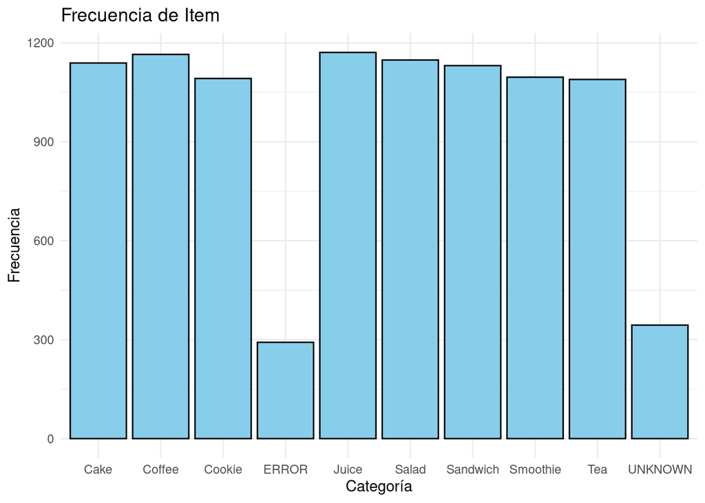

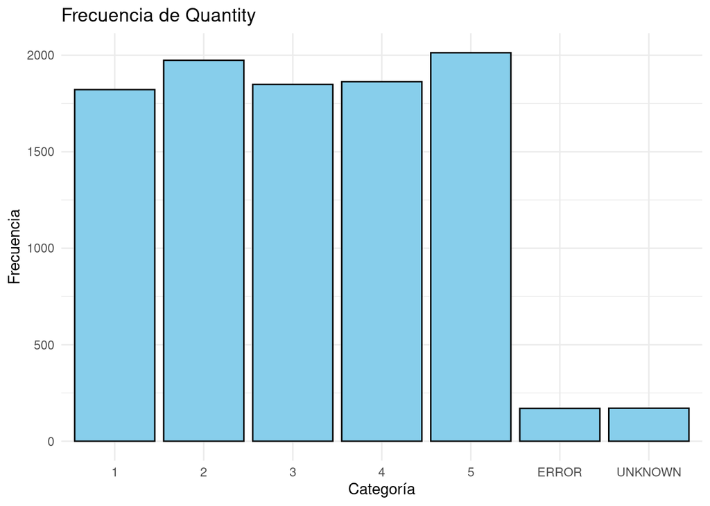

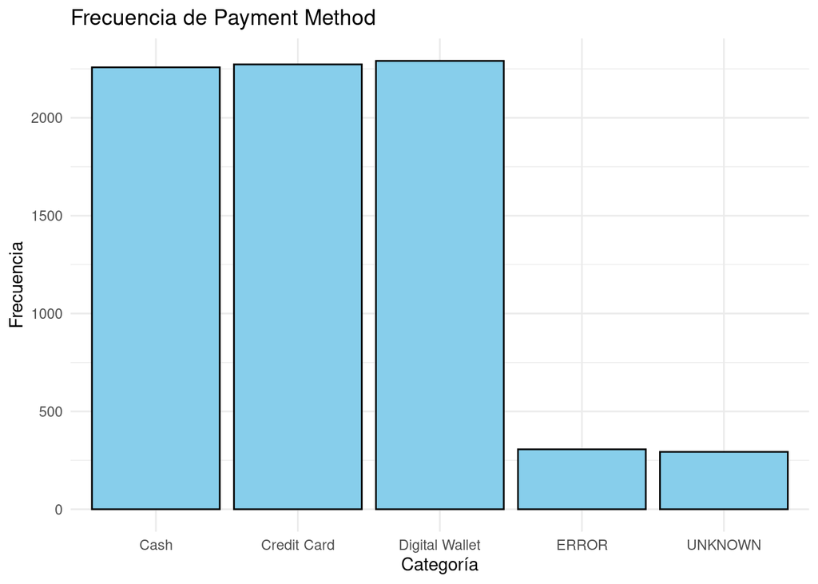

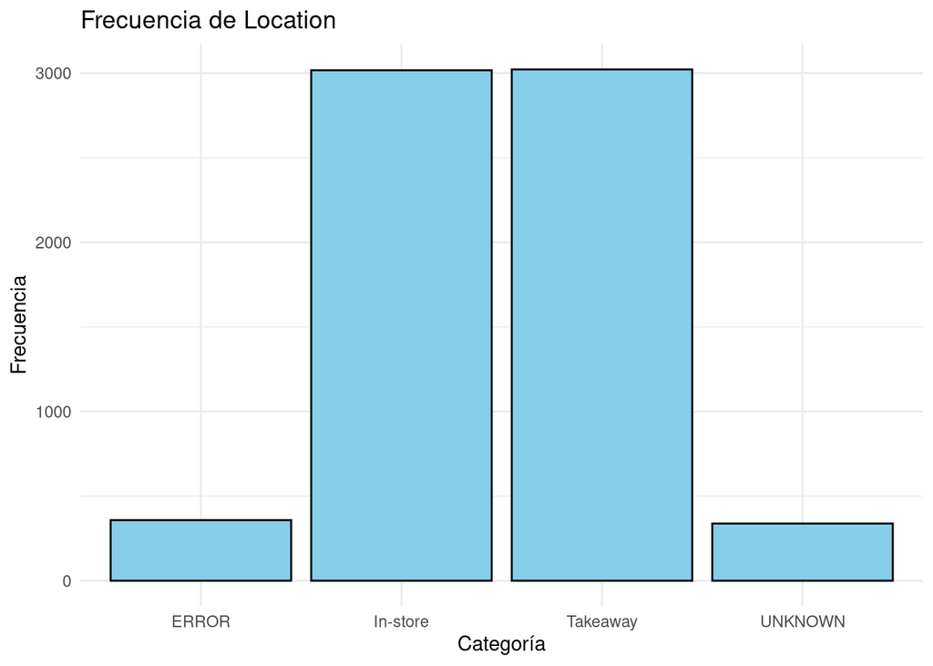

```r
# Grafico las frecuencias
for (col_name in names(df)) {
    freqs <- table(df[[col_name]])
    ggplot(data = as.data.frame(freqs), aes(x = Var1, y = Freq)) +
      geom_bar(stat = "identity", fill = "skyblue", color = "black") +
      labs(title = paste("Frecuencia de", col_name), x = "Categoría", y = "Frecuencia") +
      theme_minimal() -> p  # Guarda el gráfico en una variable

    print(p)  # Muestra el gráfico
  }
```

## 1.3 Cuántos nulos?

```r
# Hago una función para contar NA, "UNKNOWN" y "ERROR"
count_values <- function(col, relative = FALSE) {
  total <- length(col)  # Total de valores en la columna

  if (is.factor(col) || is.character(col)) {
    counts <- c(
      NA_count = sum(is.na(col)),
      UNKNOWN_count = sum(col == "UNKNOWN", na.rm = TRUE),
      ERROR_count = sum(col == "ERROR", na.rm = TRUE)
    )
  } else {
    counts <- c(
      NA_count = sum(is.na(col)),
      UNKNOWN_count = NA,
      ERROR_count = NA
    )
  }

  # Si relative = TRUE, convierte a proporciones
  if (relative) {
    counts <- counts / total
  }

  return(counts)
}


# Aplico la función a todas las columnas del data.frame
result_F <- sapply(df, count_values)


print(as.data.frame(t(result_F)))
```

```
##                NA_count UNKNOWN_count ERROR_count
## Item                333           344         292
## Quantity            138           171         170
## Payment Method     2579           293         306
## Location           3265           338         358
```

## 1.4 Análisis

Las columnas `Item`, `Quantity`, `Payment Method` y `Location` parecen tener una distribución uniforme, a excepción de los valores `UNKNOWN` y `ERROR`. El `Item` más frecuente de la tabla es `Juice`, la `Quantity` menos frecuente es `1`, `2258` personas pagaron en `Cash`, la cantidad de `NA`, `UNKNOWN` y `ERROR` para location son, respectivamente, `3265`, `338` y `358`.  
Ahora veo `Price per Unit`:

```r
# Agarro price per unit como dataframe
price_per_unit <- as.data.frame(select(cafe_sales_df, "Price Per Unit"))

# Fuerzo a convertir a número
price_per_unit$`Price Per Unit` <- as.numeric(price_per_unit$`Price Per Unit`)
# Limpio los Nan
price_per_unit <- price_per_unit[!is.na(price_per_unit$`Price Per Unit`), , drop = TRUE]
```

```r
print(paste("Media", mean(price_per_unit)))
```

```
## [1] "Media 2.94998415548748"
```

```r
print(paste("Mediana", median(price_per_unit)))
```

```
## [1] "Mediana 3"
```

```r
print(paste("STD", sd(price_per_unit)))
```

```
## [1] "STD 1.27845047280359"
```

# 2 Análisis de Outliers y Patrones Temporales

## 2.1 Outliers

No tiene sentido que me fije outliers en `Transaction ID` y `Transaction Date`. Además en `Item`, `Quantity`, `Payment Method` y `Location` ya me fijé antes viendo las frecuencias, ya que son variables categóricas. Voy a ver el resto

```r
# Selecciono las columnas
df <- as.data.frame(select(cafe_sales_df, "Price Per Unit", "Total Spent"))

# Lo convierto a numeros
df <- df %>% mutate_all(~ suppressWarnings(as.numeric(.)))

# Le saco los nans
df <- na.omit(df)
```

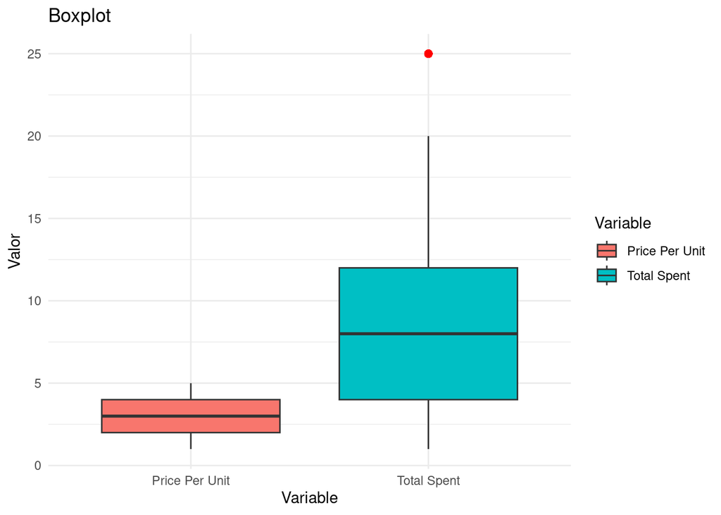

```r
# Convertir a formato largo (long format)
df_long <- pivot_longer(df, cols = everything(), names_to = "Variable", values_to = "Valor")

# Boxplot de ambas columnas
ggplot(df_long, aes(x = Variable, y = Valor, fill = Variable)) +
  geom_boxplot(outlier.color = "red", outlier.size = 2) +
  labs(title = "Boxplot", x = "Variable", y = "Valor") +
  theme_minimal()
```

```r
Q1 <- quantile(total_spent, 0.25, na.rm = TRUE)
Q3 <- quantile(total_spent, 0.75, na.rm = TRUE)
IQR <- Q3 - Q1
lower_bound <- Q1 - 1.5 * IQR
upper_bound <- Q3 + 1.5 * IQR
```

## 2.2 Analizo `Transaction Date`

```r
# Paso transaction date a date
cafe_sales_df$`Transaction Date` <- as.Date(cafe_sales_df$`Transaction Date`, format = "%Y-%m-%d")

# Armo nueva columna "dia_de_semana"
cafe_sales_df$dia_de_semana <- format(cafe_sales_df$`Transaction Date`, "%A")

cafe_sales_df$dia_de_semana <- factor(
  cafe_sales_df$dia_de_semana, levels = c("lunes", "martes", "miércoles", "jueves", "viernes", "sábado", "domingo")
)
```

```r
# transacciones por día de la semana
transacciones_x_dia <- cafe_sales_df %>%
  group_by(dia_de_semana) %>%
  summarise(total_transacciones = n()) %>%  # n() calcula el numero de filas
  arrange(dia_de_semana) # ordeno por dia de semana

print(transacciones_x_dia)
```

```
## # A tibble: 8 × 2
##   dia_de_semana total_transacciones
##   <fct>                       <int>
## 1 lunes                        1382
## 2 martes                       1311
## 3 miércoles                    1341
## 4 jueves                       1380
## 5 viernes                      1388
## 6 sábado                       1358
## 7 domingo                      1380
## 8 <NA>                          460
```

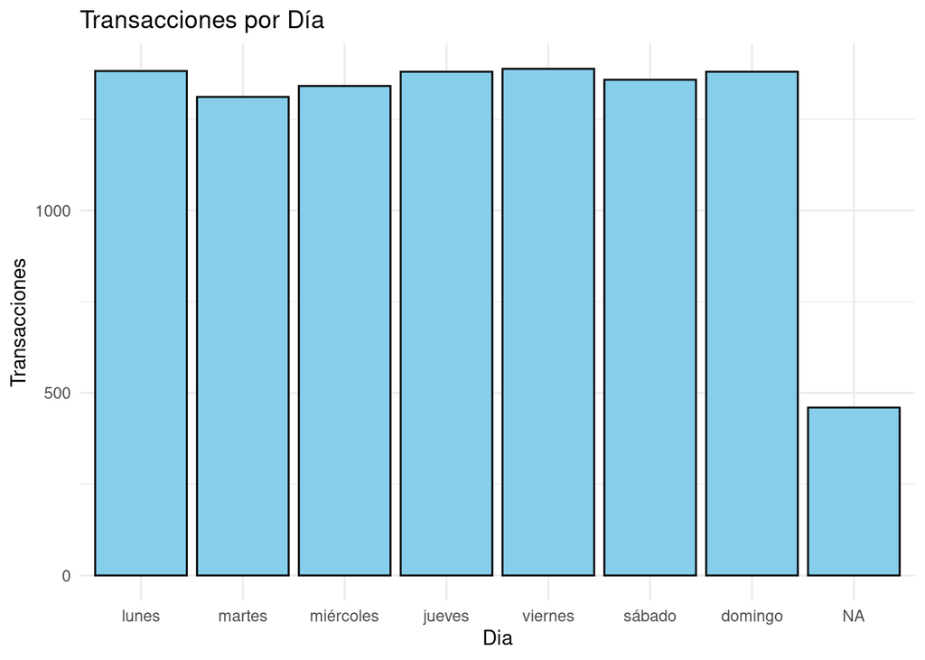

```r
ggplot(data = as.data.frame(transacciones_x_dia), aes(x = dia_de_semana, y = total_transacciones)) +
  geom_bar(stat = "identity", fill = "skyblue", color = "black") +
  labs(title = "Transacciones por Día", x = "Dia", y = "Transacciones") +
  theme_minimal()
```

Con esta información vemos que la cantidad de transacciones por día es homogénea, con minimo los martes y máximo los viernes.  
Vamos a ver la serie mensual

```r
# Crear nueva columna "mes"
cafe_sales_df$mes <- format(cafe_sales_df$`Transaction Date`, "%B")

cafe_sales_df$mes <- factor(
  cafe_sales_df$mes, levels = c("enero", "febrero", "marzo", "abril", "mayo", "junio", "julio", "agosto", "septiembre", "octubre", "noviembre", "diciembre")
)

# transacciones por mes
transacciones_x_mes <- cafe_sales_df %>%
  group_by(mes) %>%
  summarise(total_transacciones = n()) %>%  # n() calcula el numero de filas
  arrange(total_transacciones) # ordeno por total de transaciones

print(transacciones_x_mes)
```

```
## # A tibble: 13 × 2
##    mes        total_transacciones
##    <fct>                    <int>
##  1 <NA>                       460
##  2 febrero                    727
##  3 abril                      774
##  4 mayo                       777
##  5 noviembre                  784
##  6 septiembre                 788
##  7 julio                      791
##  8 diciembre                  795
##  9 agosto                     803
## 10 enero                      818
## 11 junio                      818
## 12 marzo                      827
## 13 octubre                    838
```

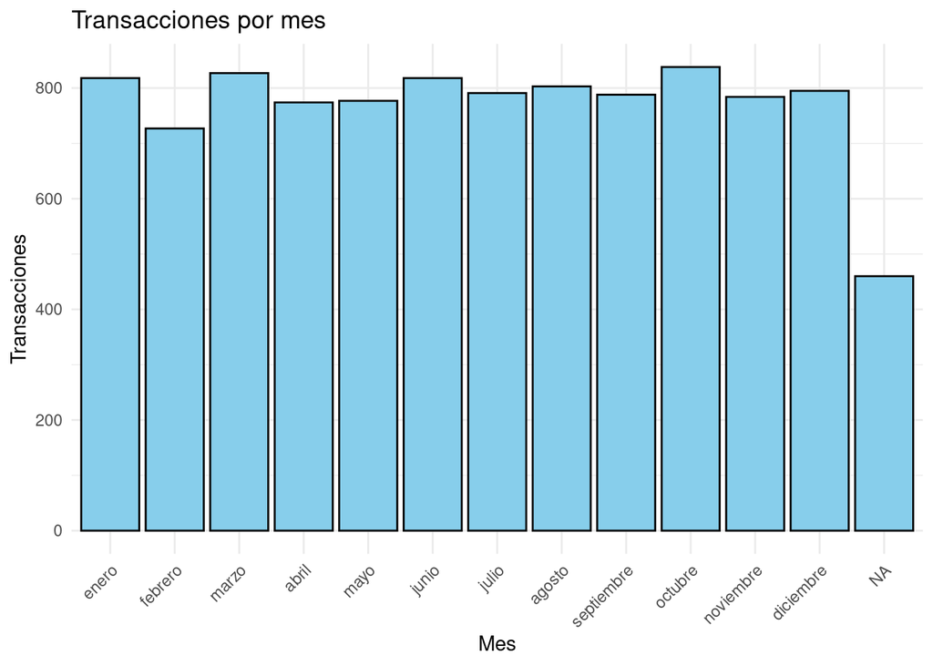

```r
ggplot(data = as.data.frame(transacciones_x_mes), aes(x = mes, y = total_transacciones)) +
  geom_bar(stat = "identity", fill = "skyblue", color = "black") +
  labs(title = "Transacciones por mes", x = "Mes", y = "Transacciones") +
  theme_minimal() + # Guarda el gráfico en una variable
  theme(axis.text.x = element_text(angle = 45, hjust = 1))
```

No se observa una tendencia clara. El mes con menos transacciones es febrero y el que más octubre, pero no se observa una evolución mes a mes, si no más bien una distribución uniforme de la cantidad de transacciones.

# 3 Completar y corregir

## 3.1 Completo `Price Per Unit` con el menú dado

```r
menu_df <- data.frame(
  Item = c("Cake", "Juice", "Coffee", "Cookie", "Salad", "Sandwich", "Smoothie", "Tea"),
  Price_Per_Unit = c(3, 3, 2, 1, 5, 4, 4, 2)
)
```

```r
cafe_sales_df <- cafe_sales_df %>%
  mutate(`Price Per Unit` = case_when(  # aplico condiciones
    # Si Price Per Unit es inválido Y el Item también es inválido → NA
    `Price Per Unit` %in% c(NA, "ERROR", "UNKNOWN") &
      (is.na(Item) | Item %in% c("ERROR", "UNKNOWN")) ~ NA_real_,
    # Si Price Per unit es inválido pero tengo Item
    `Price Per Unit` %in% c(NA, "ERROR", "UNKNOWN") &
      !(is.na(Item) | Item %in% c("ERROR", "UNKNOWN")) ~ menu_df$Price_Per_Unit[match(Item, menu_df$Item)],
    # si está bien lo hago numerico
    TRUE ~ as.numeric(`Price Per Unit`)
  ))
```

## 3.2 Completo la `Quantity`, `Price Per Unit` y `Total Spent`

```r
# Me quedo con las filas que le falta solo 1 dato
df_1_nans <- cafe_sales_df %>%
  filter(countNans == 1)
```

```r
# Corrijo las que le falten un solo dato
cafe_sales_df <- cafe_sales_df %>%
  mutate(
    `Total Spent` = ifelse(countNans == 1 & is.na(`Total Spent`) & !is.na(Quantity) & !is.na(`Price Per Unit`),
                           Quantity * `Price Per Unit`, `Total Spent`),

    Quantity = ifelse(countNans == 1 & is.na(Quantity) & !is.na(`Total Spent`) & !is.na(`Price Per Unit`),
                      `Total Spent` / `Price Per Unit`, Quantity),

    `Price Per Unit` = ifelse(countNans == 1 & is.na(`Price Per Unit`) & !is.na(`Total Spent`) & !is.na(Quantity),
                              `Total Spent` / Quantity, `Price Per Unit`)
  )
```

## 3.3 Completo `Item` desde `Price Per Unit`

```r
# Corrijo los items faltantes con el precio del menu
cafe_sales_df <- cafe_sales_df %>%
  mutate(
    Item = case_when(
      (is.na(Item) | Item %in% c("UNKNOWN", "ERROR")) & `Price Per Unit` == 1 ~ "Cookie",
      (is.na(Item) | Item %in% c("UNKNOWN", "ERROR")) & `Price Per Unit` == 3 ~ "Cake",
      (is.na(Item) | Item %in% c("UNKNOWN", "ERROR")) & `Price Per Unit` == 4 ~ "Sandwich",
      (is.na(Item) | Item %in% c("UNKNOWN", "ERROR")) & `Price Per Unit` == 5 ~ "Salad",

      TRUE ~ Item
    )
  )
```

## 3.4 Verifico

```r
contar_na <- function(df, columna) {
  sum(is.na(df[[columna]]))
}

contar_na(cafe_sales_df, "Item")
```

```
## [1] 81
```

```r
contar_na(cafe_sales_df, "Price Per Unit")
```

```
## [1] 6
```

```r
contar_na(cafe_sales_df, "Quantity")
```

```
## [1] 23
```

```r
contar_na(cafe_sales_df, "Total Spent")
```

```
## [1] 23
```

Bueno considero que esto es incluso mejor que lo que piden así que sigo.

## 3.5 Relleno columnas usando la moda

```r
# Función para calcular la moda, excluyendo NA, "ERROR" y "UNKNOWN"
calcular_moda <- function(col) {
  col_filtrado <- col[!is.na(col) & col != "ERROR" & col != "UNKNOWN"]
  if (length(col_filtrado) == 0) {
    return(NA)  # Si no hay datos válidos
  }
  unicos <- unique(col_filtrado)
  moda <- unicos[which.max(tabulate(match(col_filtrado, unicos)))]
  return(moda)
}

# Reemplazar valores en las columnas deseadas
columnas_a_rellenar <- c("Item", "Price Per Unit", "Quantity", "Total Spent", "Payment Method", "Location")

# Aplicar la moda a cada columna y reemplazar valores anómalos
for (col in columnas_a_rellenar) {
  moda_col <- calcular_moda(cafe_sales_df[[col]])

  cafe_sales_df[[col]] <- ifelse(
    is.na(cafe_sales_df[[col]]) | cafe_sales_df[[col]] == "ERROR" | cafe_sales_df[[col]] == "UNKNOWN",
    moda_col,
    cafe_sales_df[[col]]
  )
}
```

Para `Transaction Date` rellenar con la moda no tiene sentido. Pero bueno lo voy a hacer igual porque los Transaction ID no están en orden …

```r
# LEvanto de nuevo los datos para que esten en formato "CHAR"
temp_df <- read_csv(file)
moda_transaction_dates <- calcular_moda(temp_df$`Transaction Date`)
cafe_sales_df$`Transaction Date` <- temp_df$`Transaction Date`
cafe_sales_df[["Transaction Date"]] <- ifelse(
  is.na(cafe_sales_df[["Transaction Date"]]) | cafe_sales_df[["Transaction Date"]] == "ERROR" | cafe_sales_df[["Transaction Date"]] == "UNKNOWN",
  moda_transaction_dates,
  cafe_sales_df[["Transaction Date"]]
)
```

```r
# Le saco las columnas de los días que tienen nan todavía
cafe_sales_df <- cafe_sales_df %>%
  select(-dia_de_semana, -mes)

print(cafe_sales_df %>%
  filter(if_any(everything(), is.na))
)
```

```
## # A tibble: 0 × 9
## # ℹ 9 variables: Transaction ID <chr>, Item <chr>, Quantity <dbl>,
## #   Price Per Unit <dbl>, Total Spent <dbl>, Payment Method <chr>,
## #   Location <chr>, Transaction Date <chr>, countNans <dbl>
```